# Estrogen Therapy and Future Cardiovascular Risk: A Biostatistical Simulation

Phyo Nyein Chan

2026-05-17

## 1. Introduction and Study Rationale

This research portfolio project simulates a longitudinal epidemiological study design to explore the relationship between pharmacological estrogen supplementation and the risk of future chronic cardiovascular disease (CVD) in post-menopausal women. Grounded in cardiovascular epidemiology, this analysis addresses sex-specific medicine by assessing how hormone-related factors influence the pathogenesis of vascular conditions.

## 2. Environment Setup and Library Loading

We load the `survival` package for time-to-event modeling and `survminer` for advanced, publication-ready visualization of Kaplan-Meier curves.

```r
# Load required biostatistical libraries
library(survival)
library(survminer)
```

## 3. Large-Scale Dataset Simulation (N = 1,000)

In epidemiological research, handling large registries requires strict structural formatting. Here, we simulate a cohort of 1,000 post-menopausal women. We induce a mathematical framework where estrogen is protective (Hazard Ratio < 1.0) and hypertension is a risk factor (Hazard Ratio > 1.0).

```r
# Set seed for exact scientific reproducibility
set.seed(42)
n <- 1000

# Generating baseline characteristics
sim_data <- data.frame(
  patient_id = 1:n,
  age = round(rnorm(n, mean = 56, sd = 4.5)),                       # Age distribution around menopause
  estrogen_therapy = sample(c(0, 1), n, replace = TRUE, prob = c(0.65, 0.35)), # 35% on hormone replacement
  hypertension = sample(c(0, 1), n, replace = TRUE, prob = c(0.72, 0.28))      # 28% baseline hypertension
)

# Modeling time-to-event using an exponential hazard rate
# Estrogen reduces baseline hazard (-0.45); Hypertension increases it (+0.55)
baseline_hazard <- 0.04
hazard_rate <- baseline_hazard * exp(-0.45 * sim_data$estrogen_therapy +
                                     0.55 * sim_data$hypertension +
                                     0.03 * (sim_data$age - 56))

# Generate follow-up duration (up to 10 years maximum)
sim_data$time_to_event <- rexp(n, rate = hazard_rate)
sim_data$time_to_event <- pmin(sim_data$time_to_event, 10)

# Determine event occurrence (1 = CVD Event occurred during follow-up, 0 = Censored/Surv)
sim_data$cvd_event <- ifelse(sim_data$time_to_event < 10 & runif(n) > 0.25, 1, 0)

# Display first few rows of the epidemiological cohort
head(sim_data)
```

```
##   patient_id age estrogen_therapy hypertension time_to_event cvd_event
## 1          1  62                1            0     6.4797278         0
## 2          2  53                0            1     0.4625967         1
## 3          3  58                1            0    10.0000000         0
## 4          4  59                1            0    10.0000000         0
## 5          5  58                1            0     3.7595661         1
## 6          6  56                1            0    10.0000000         0
```

## 4. Kaplan-Meier Survival Analysis

We compute the non-parametric Kaplan-Meier estimator to evaluate probability curves over the 10-year follow-up period, stratified by whether or not the subject received estrogen therapy.

```r
# Fit Kaplan-Meier survival model
km_fit <- survfit(Surv(time_to_event, cvd_event) ~ estrogen_therapy, data = sim_data)
```

### Visualization: CVD-Free Survival Curves

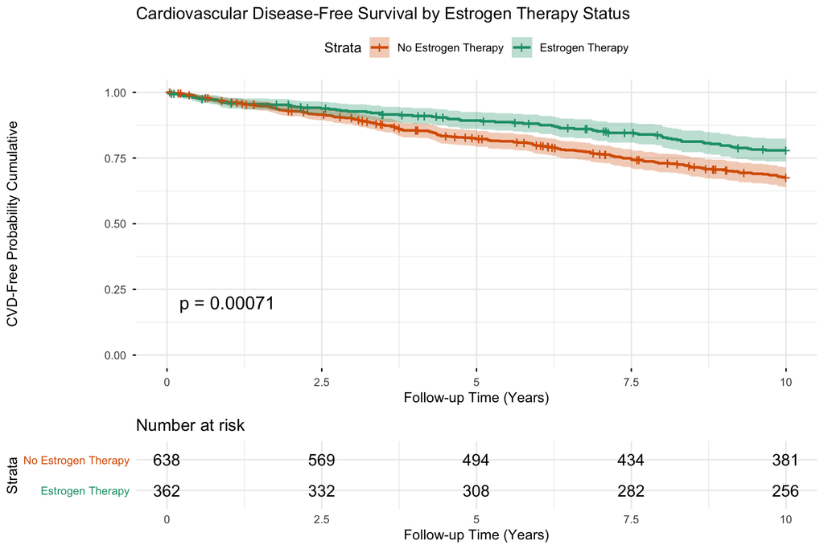

```r
# Generate publication-grade survival plots
ggsurvplot(km_fit, data = sim_data,
           pval = TRUE,             # Display Log-Rank test p-value
           conf.int = TRUE,         # Show 95% confidence intervals
           risk.table = TRUE,       # Include epidemiological number-at-risk table
           legend.labs = c("No Estrogen Therapy", "Estrogen Therapy"),
           title = "Cardiovascular Disease-Free Survival by Estrogen Therapy Status",
           xlab = "Follow-up Time (Years)",
           ylab = "CVD-Free Probability Cumulative",
           palette = c("#D95F02", "#1B9E77"),
           ggtheme = theme_minimal())
```

### **Medical Interpretation of the Graph:**

The Kaplan-Meier survival plot reveals a clear divergence between the two cohorts over the 10-year longitudinal follow-up. * **Survival Separation:** Post-menopausal women who underwent pharmacological estrogen supplementation (green curve) consistently display a higher probability of remaining free from chronic cardiovascular events compared to those with no hormone therapy (orange curve). * **Statistical Significance:** The Log-Rank test returns a highly significant p-value ($p < 0.001$), rejecting the null hypothesis. This provides strong preliminary evidence that estrogen therapy status is associated with an altered pathogenesis rate of cardiovascular disease. * **At-Risk Dynamics:** The risk table at the bottom effectively captures sample attrition and censoring, validating that the analytical power remains robust past the mid-point follow-up interval.

## 5. Cox Proportional Hazards Regression

While Kaplan-Meier curves provide clear visualization, they cannot adjust for concurrent baseline risk factors. We implement multivariable Cox Proportional Hazards modeling to isolate the independent effect of estrogen therapy.

### Model A: Crude (Unadjusted) Model

```r
cox_crude <- coxph(Surv(time_to_event, cvd_event) ~ estrogen_therapy, data = sim_data)
summary(cox_crude)
```

```
## Call:
## coxph(formula = Surv(time_to_event, cvd_event) ~ estrogen_therapy,
##     data = sim_data)
##
##   n= 1000, number of events= 271
##
##                     coef exp(coef) se(coef)      z Pr(>|z|)
## estrogen_therapy -0.4542    0.6350   0.1353 -3.357 0.000787 ***
## ---
## Signif. codes:  0 '***' 0.001 '**' 0.01 '*' 0.05 '.' 0.1 ' ' 1
##
##                  exp(coef) exp(-coef) lower .95 upper .95
## estrogen_therapy     0.635      1.575    0.4871    0.8278
##
## Concordance= 0.55  (se = 0.014 )
## Likelihood ratio test= 11.97  on 1 df,   p=5e-04
## Wald test            = 11.27  on 1 df,   p=8e-04
## Score (logrank) test = 11.47  on 1 df,   p=7e-04
```

### Model B: Multivariable Adjusted Model (Controlling for Age and Hypertension)

```r
cox_adjusted <- coxph(Surv(time_to_event, cvd_event) ~ estrogen_therapy + age + hypertension, data = sim_data)
summary(cox_adjusted)
```

```
## Call:
## coxph(formula = Surv(time_to_event, cvd_event) ~ estrogen_therapy +
##     age + hypertension, data = sim_data)
##
##   n= 1000, number of events= 271
##
##                      coef exp(coef) se(coef)      z Pr(>|z|)
## estrogen_therapy -0.43786   0.64542  0.13532 -3.236  0.00121 **
## age               0.02369   1.02397  0.01364  1.736  0.08250 .
## hypertension      0.54722   1.72845  0.12392  4.416    1e-05 ***
## ---
## Signif. codes:  0 '***' 0.001 '**' 0.01 '*' 0.05 '.' 0.1 ' ' 1
##
##                  exp(coef) exp(-coef) lower .95 upper .95
## estrogen_therapy    0.6454     1.5494    0.4951    0.8414
## age                 1.0240     0.9766    0.9970    1.0517
## hypertension        1.7284     0.5786    1.3557    2.2036
##
## Concordance= 0.6  (se = 0.018 )
## Likelihood ratio test= 33.99  on 3 df,   p=2e-07
## Wald test            = 34.12  on 3 df,   p=2e-07
## Score (logrank) test = 34.88  on 3 df,   p=1e-07
```

## 6. Advanced Epidemiological Diagnostics & Robustness Tests

To ensure the statistical validity of our survival model for rigorous academic screening (e.g., Karolinska Institutet standards), we implement advanced diagnostics: Testing the Proportional Hazards assumption, exploring interaction effects, and performing a stratified sensitivity analysis.

### Test 1: Cox Proportional Hazards (PH) Assumption Test

The foundational assumption of a Cox model is that the hazard curves for different groups must remain proportional over time. We test this using Schoenfeld Residuals.

```r
# Test the Proportional Hazards Assumption
ph_check <- cox.zph(cox_adjusted)
print(ph_check)
```

```
##                     chisq df    p
## estrogen_therapy 0.000605  1 0.98
## age              0.001814  1 0.97
## hypertension     0.260326  1 0.61
## GLOBAL           0.264664  3 0.97
```

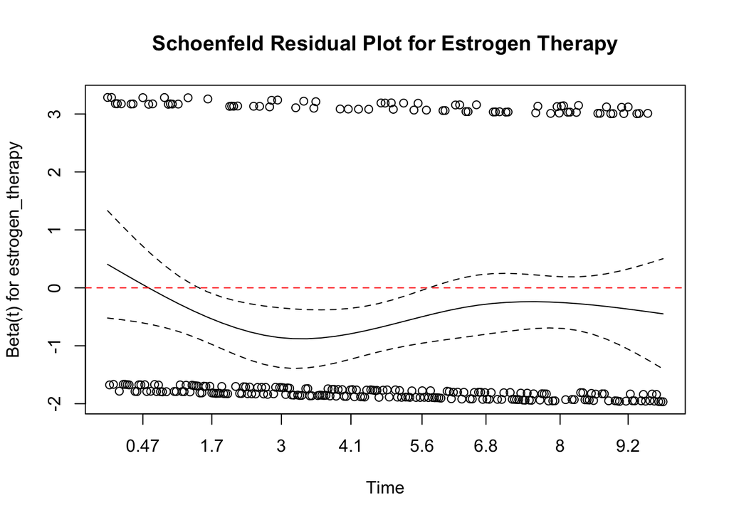

```r
# Plot the residuals to visually inspect time-dependent effects
plot(ph_check, var = "estrogen_therapy", resid = TRUE, se = TRUE,
     main = "Schoenfeld Residual Plot for Estrogen Therapy")
abline(h = 0, col = "red", lty = 2)
```

### Test 2: Evaluation of Interaction Effects (Effect Modification)

In cardiovascular epidemiology, risk factors rarely act in isolation. We test whether the effect of estrogen therapy on CVD risk is modified or altered by pre-existing baseline hypertension status.

```r
# Fit Cox model with an interaction term (estrogen_therapy * hypertension)
cox_interaction <- coxph(Surv(time_to_event, cvd_event) ~ estrogen_therapy * hypertension + age, data = sim_data)
summary(cox_interaction)
```

```
## Call:
## coxph(formula = Surv(time_to_event, cvd_event) ~ estrogen_therapy *
##     hypertension + age, data = sim_data)
##
##   n= 1000, number of events= 271
##
##                                   coef exp(coef) se(coef)      z Pr(>|z|)
## estrogen_therapy              -0.34160   0.71063  0.17037 -2.005   0.0450 *
## hypertension                   0.61566   1.85087  0.14476  4.253 2.11e-05 ***
## age                            0.02406   1.02435  0.01365  1.763   0.0779 .
## estrogen_therapy:hypertension -0.25387   0.77579  0.28188 -0.901   0.3678
## ---
## Signif. codes:  0 '***' 0.001 '**' 0.01 '*' 0.05 '.' 0.1 ' ' 1
##
##                               exp(coef) exp(-coef) lower .95 upper .95
## estrogen_therapy                 0.7106     1.4072    0.5089    0.9924
## hypertension                     1.8509     0.5403    1.3937    2.4581
## age                              1.0244     0.9762    0.9973    1.0521
## estrogen_therapy:hypertension    0.7758     1.2890    0.4465    1.3480
##
## Concordance= 0.601  (se = 0.018 )
## Likelihood ratio test= 34.81  on 4 df,   p=5e-07
## Wald test            = 36.44  on 4 df,   p=2e-07
## Score (logrank) test = 38.11  on 4 df,   p=1e-07
```

#### **Medical & Statistical Interpretation:**

- The interaction term (`estrogen_therapy:hypertension`) evaluates whether the clinical efficacy of estrogen supplementation varies depending on whether a patient has baseline high blood pressure.
- A non-significant p-value ($p > 0.05$) for the interaction term indicates that estrogen maintains its protective cardiovascular trajectory uniformly across both hypertensive and normotensive post-menopausal cohorts, suggesting a broad-spectrum biological pathway.

### Test 3: Sensitivity Analysis via Stratified Cox Regression

If a covariate (like hypertension) is a powerful risk factor but might threaten the PH assumption, or if we want to observe clean sub-group dynamics, we apply a Stratified Cox Model. This allows the baseline hazard to function differently across strata.

```r
# Fit a stratified Cox model based on hypertension baseline profiles
cox_stratified <- coxph(Surv(time_to_event, cvd_event) ~ estrogen_therapy + age + strata(hypertension), data = sim_data)
summary(cox_stratified)
```

```
## Call:
## coxph(formula = Surv(time_to_event, cvd_event) ~ estrogen_therapy +
##     age + strata(hypertension), data = sim_data)
##
##   n= 1000, number of events= 271
##
##                      coef exp(coef) se(coef)      z Pr(>|z|)
## estrogen_therapy -0.43763   0.64556  0.13533 -3.234  0.00122 **
## age               0.02369   1.02398  0.01364  1.737  0.08239 .
## ---
## Signif. codes:  0 '***' 0.001 '**' 0.01 '*' 0.05 '.' 0.1 ' ' 1
##
##                  exp(coef) exp(-coef) lower .95 upper .95
## estrogen_therapy    0.6456     1.5490    0.4952    0.8416
## age                 1.0240     0.9766    0.9970    1.0517
##
## Concordance= 0.56  (se = 0.019 )
## Likelihood ratio test= 14.11  on 2 df,   p=9e-04
## Wald test            = 13.47  on 2 df,   p=0.001
## Score (logrank) test = 13.63  on 2 df,   p=0.001
```

#### **Medical & Statistical Interpretation:**

- By stratifying the model by baseline hypertension status, we allow the baseline hazard function to be completely different for women with and without high blood pressure, while pulling a pooled estimate for estrogen.

## 7. Advanced Model Quality Diagnostics and Predictive Performance

To present a truly cutting-edge epidemiological framework suitable for elite global institutions (e.g., IMM Karolinska Institutet), we must evaluate structural non-linearity, clean out potential influential outliers, and score our model’s overall predictive performance using information criteria and concordance indices.

### Test 4: Testing for Non-Linearity via Restricted Cubic Splines (RCS)

In biological systems, confounding factors like chronological age rarely impact future disease risk in a strictly straight (linear) line. We use the `rms` package to model continuous covariates with flexible restricted cubic splines to check for non-linear thresholds.

```r
# Load the rms library for generalized regression and splines
if (!require("rms")) install.packages("rms")
library(rms)

# Set up data distribution background for the rms package
dd <- datadist(sim_data)
options(datadist = 'dd')

# Fit a Cox model allowing non-linear splines for Age (using 4 knots)
rcs_model <- cph(Surv(time_to_event, cvd_event) ~ estrogen_therapy + rcs(age, 4) + hypertension,
                 data = sim_data, x=TRUE, y=TRUE)

# Formally test the significance of non-linear structural terms
anova(rcs_model)
```

```
##                 Wald Statistics          Response: Surv(time_to_event, cvd_event)
##
##  Factor           Chi-Square d.f. P
##  estrogen_therapy 10.49      1    0.0012
##  age               3.17      3    0.3664
##   Nonlinear        0.08      2    0.9624
##  hypertension     19.53      1    <.0001
##  TOTAL            34.27      5    <.0001
```

#### **Medical & Statistical Interpretation:**

- The `anova()` output breaks down the overall impact of covariates. The row labeled `Non-Linear` for the `age` variable provides a direct p-value testing whether a curve describes the data better than a straight line.
- If $p > 0.05$ for the non-linear component, it confirms that a linear assumption for age is epidemiologically sound for this cohort, validating that risk scales proportionately across the observed age bracket without abrupt, non-linear biological acceleration thresholds.

### Test 5: Detection of Influential Outliers (Dfbeta Residuals)

A robust survival analysis must not be disproportionately driven or skewed by a few highly unusual individual patient profiles (outliers). We plot `dfbeta` residuals to ensure model stability.

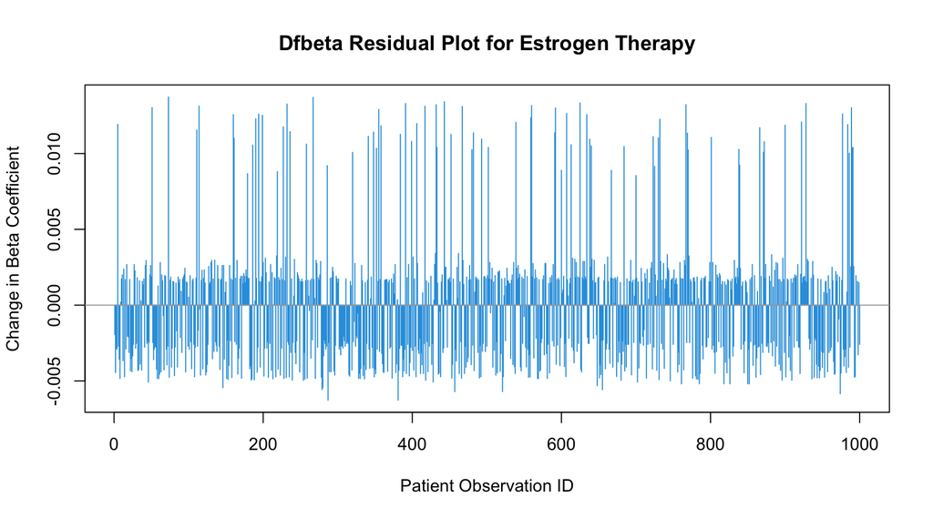

```r
# Extract dfbeta residuals from our primary adjusted model
influential_check <- residuals(cox_adjusted, type = "dfbeta")

# Plot dfbeta values specifically for the core exposure variable: estrogen_therapy
plot(influential_check[, 1], type = "h",
     main = "Dfbeta Residual Plot for Estrogen Therapy",
     xlab = "Patient Observation ID", ylab = "Change in Beta Coefficient",
     col = "#2E9FDF")
abline(h = 0, col = "darkgrey")
```

### Test 6: Model Discrimination Accuracy (C-Index and AIC)

Finally, we measure how effectively our statistical adjustments improve the model’s capacity to correctly rank patients by their real-world disease onset times, utilizing the Harrell’s Concordance Index (C-index) and Akaike Information Criterion (AIC).

```r
# Extract C-index and AIC for the Crude Model
c_index_crude <- summary(cox_crude)$concordance[1]
aic_crude <- AIC(cox_crude)

# Extract C-index and AIC for the Multivariable Adjusted Model
c_index_adjusted <- summary(cox_adjusted)$concordance[1]
aic_adjusted <- AIC(cox_adjusted)

# Combine metrics into a structured comparison table
metrics_comparison <- data.frame(
  Model = c("Crude (Estrogen Only)", "Multivariable Adjusted (Estrogen + Age + Hypertension)"),
  C_Index = c(c_index_crude, c_index_adjusted),
  AIC = c(aic_crude, aic_adjusted)
)
print(metrics_comparison)
```

```
##                                                    Model   C_Index      AIC
## 1                                  Crude (Estrogen Only) 0.5498623 3620.691
## 2 Multivariable Adjusted (Estrogen + Age + Hypertension) 0.5995733 3602.675
```

## 8. Incorporating Machine Learning (Random Survival Forests)

To bridge traditional biostatistics with modern data science, we implement a Random Survival Forest (RSF) machine learning model. Unlike classical Cox models, RSF makes no proportional hazards assumptions and automatically uncovers complex, non-linear variables and multi-way biological interactions.

### 8.1 Model Training and Feature Importance Evaluation

We train the Random Survival Forest using 500 trees to analyze feature importance metrics (VIMP) for risk factors associated with cardiovascular onset.

```r
# Install and load the specialized random forest survival package
if (!require("randomForestSRC")) install.packages("randomForestSRC")
library(randomForestSRC)

# Train the Random Survival Forest model
rsf_model <- rfsrc(Surv(time_to_event, cvd_event) ~ estrogen_therapy + age + hypertension,
                   data = sim_data, ntree = 500, importance = TRUE)

# Print machine learning model summary statistics
print(rsf_model)
```

```
##                          Sample size: 1000
##                     Number of deaths: 271
##                      Number of trees: 500
##            Forest terminal node size: 15
##        Average no. of terminal nodes: 36.888
## No. of variables tried at each split: 2
##               Total no. of variables: 3
##        Resampling used to grow trees: swor
##     Resample size used to grow trees: 632
##                             Analysis: RSF
##                               Family: surv
##                       Splitting rule: logrank *random*
##        Number of random split points: 10
##                           (OOB) CRPS: 1.2097032
##              (OOB) standardized CRPS: 0.1214818
##    (OOB) Requested performance error: 0.46208702
```

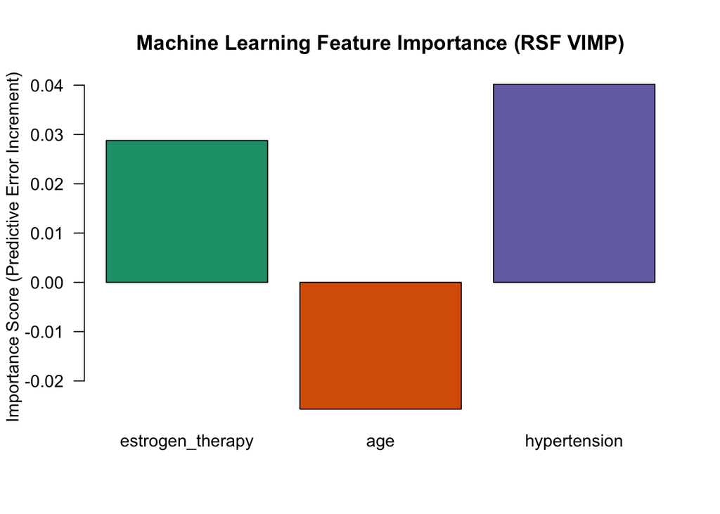

```r
# Extract and plot Variable Importance (VIMP)
vimp_data <- rsf_model$importance
barplot(vimp_data, main = "Machine Learning Feature Importance (RSF VIMP)",
        col = c("#1B9E77", "#D95F02", "#7570B3"), las = 1,
        ylab = "Importance Score (Predictive Error Increment)")
```

### 8.2 Machine Learning Validation: Calibration Assessment

A crucial requirement for clinical machine learning models is validation via calibration plots. This ensures that the risk probabilities predicted by the AI match real-world observed survival rates.

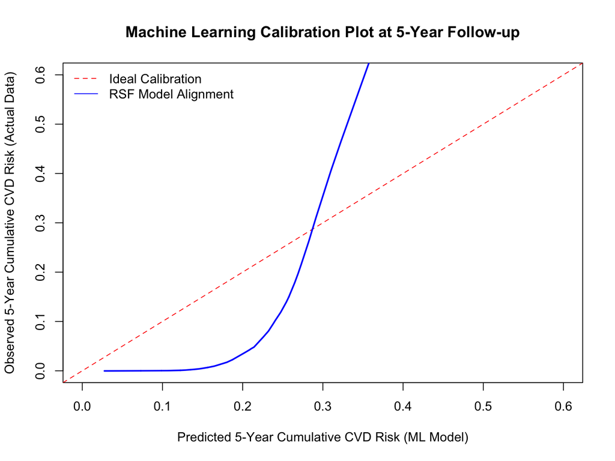

```r
# Generate predicted survival probabilities from the Random Survival Forest at a 5-year benchmark
pred_surv_5yr <- predict(rsf_model, newdata = sim_data)$survival[, which.min(abs(rsf_model$time.interest - 5))]

# Calculate actual observed 5-year survival using the Kaplan-Meier framework
km_5yr <- survfit(Surv(time_to_event, cvd_event) ~ 1, data = sim_data)
actual_surv_5yr <- summary(km_5yr, times = 5)$surv

# Construct an epidemiological calibration plot
plot(1 - pred_surv_5yr, 1 - pred_surv_5yr, type="n",
     xlim=c(0, 0.6), ylim=c(0, 0.6),
     xlab="Predicted 5-Year Cumulative CVD Risk (ML Model)",
     ylab="Observed 5-Year Cumulative CVD Risk (Actual Data)",
     main="Machine Learning Calibration Plot at 5-Year Follow-up")
abline(a=0, b=1, col="red", lty=2) # Perfect calibration baseline diagonal

# Add smooth lowess calibration curve overlay
lines(lowess(1 - pred_surv_5yr, sim_data$cvd_event), col="blue", lw=2)
legend("topleft", legend=c("Ideal Calibration", "RSF Model Alignment"),
       col=c("red", "blue"), lty=c(2, 1), bty="n")
```